# Migration Pattern Analysis with Data Integration

Import, clean and merge the datasets.

```
files = list.files(
  "migration",
  pattern = "\\.xls$",
  full.names = TRUE,
  ignore.case = TRUE
)

read_migration_file = function(file_path) {
  read_excel(
    file_path,
    skip = 8,
    col_names = c(
      "dest_state_fips",
      "dest_county_fips",
      "orig_state_fips",
      "orig_county_fips",
      "state_abbr",
      "flow_description",
      "returns",
      "exemptions",
      "income_thousands"
    ),
    col_types = rep("text", 9)
  ) |>
    mutate(
      returns = parse_number(returns),
      exemptions = parse_number(exemptions),
      income_thousands = parse_number(income_thousands)
    )
}

migration_raw = map_dfr(files, read_migration_file) |>
  arrange(dest_state_fips, dest_county_fips, orig_state_fips, orig_county_fips)
```

# 1

Identify the county pairs with the most interactions (by number of exemptions).

## Method

Before analyzing migration patterns, I removed rows that did not represent meaningful county-to-county migration. Specifically, I excluded summary rows where orig_state_fips > 56, since these rows correspond to aggregated categories rather than actual U.S. counties. I also removed rows where the origin and destination counties were the same, because this project focuses on migration between counties rather than within-county records.

To identify the county pairs with the most interactions, I first created standardized county identifiers by concatenating state and county FIPS codes for both origin and destination counties. Because county-to-county migration is directional in the raw data, I reordered each pair using `pmin()` and `pmax()` so that flows between the same two counties would be treated as one undirected county pair. I then aggregated the number of exemptions across each pair and ranked the pairs from highest to lowest interaction.

To make the output more interpretable, I sourced an external county FIPS crosswalk file and used it to match county names to the county FIPS codes in the migration dataset. I then joined this lookup table back to the ranked county pairs so that the final results included both FIPS codes and county names.

```
# get rid of the summary rows and non-migration rows
migration_df = migration_raw |>
  filter(
    orig_state_fips <= 56,
    !(dest_state_fips == orig_state_fips & dest_county_fips == orig_county_fips)
  ) |>
  mutate(
    # create unique FIPS codes for each county
    dest_fips = paste0(dest_state_fips, dest_county_fips),
    orig_fips = paste0(orig_state_fips, orig_county_fips))

county_pairs = migration_df |>
  mutate(
    # create county pairs
    pair_1_fips = pmin(orig_fips, dest_fips),
    pair_2_fips = pmax(orig_fips, dest_fips)
  ) |>
  # sum exemptions for each county pair
  group_by(pair_1_fips, pair_2_fips) |>
  summarise(
    total_exemptions = sum(exemptions, na.rm = TRUE),
    .groups = "drop"
  ) |>
  arrange(desc(total_exemptions))
```

```
# create a county name lookup table
county_lookup = read_csv("County FIPS codes.csv") |>
  transmute(
    county_fips = str_pad(as.character(`County FIPS Code`), width = 5, side = "left", pad = "0"),
    state_fips = str_pad(as.character(`State FIPS code`), width = 2, side = "left", pad = "0"),
    county_state = str_replace(County, ",.*$", "") |> str_c(", ", State)
  ) |>
  janitor::clean_names()

# join county names to each county pair
top_pairs_named = county_pairs |>
  left_join(
    county_lookup |>
      rename(
        pair_1_fips = county_fips,
        pair_1_county = county_state
      ),
    by = "pair_1_fips"
  ) |>
  left_join(
    county_lookup |>
      rename(
        pair_2_fips = county_fips,
        pair_2_county = county_state
      ),
    by = "pair_2_fips"
  ) |>
  select(pair_1_fips, pair_1_county, pair_2_fips, pair_2_county, total_exemptions)

top_pairs_named |>
  head(5) |>
  knitr::kable(caption = "Table 1. Top 5 county pairs by total exemptions") |>
  kableExtra::kable_styling(full_width = FALSE)
```

Table 1. Top 5 county pairs by total exemptions

| pair_1_fips | pair_1_county | pair_2_fips | pair_2_county | total_exemptions |
| --- | --- | --- | --- | --- |
| 06037 | Los Angeles County, California | 06071 | San Bernardino County, California | 67982 |
| 06037 | Los Angeles County, California | 06059 | Orange County, California | 63896 |
| 12011 | Broward County, Florida | 12086 | Miami-Dade, Florida | 43204 |
| 17031 | Cook County, Illinois | 17043 | DuPage County, Illinois | 42666 |
| 48157 | Fort Bend County, Texas | 48201 | Harris County, Texas | 39315 |

## Result

The the county pairs with the most interactions (by number of exemptions) are shown in Table 1.

# 2

Determine which counties show the highest in-migration and out-migration.

## Method

To identify the counties with the highest in-migration and out-migration, I aggregated migration flows at the county level using the number of exemptions as the measure of migration volume. Specifically, I summed exemptions across all records for each destination county (dest_fips) to measure total in-migration, and across all records for each origin county (orig_fips) to measure total out-migration. After ranking counties in descending order of total exemptions, I joined the results with the county lookup table to attach readable county names and state abbreviations.

```
# counties with the highest in-migration
top_in_migration = migration_df |>
  group_by(dest_fips) |>
  summarise(
    total_in_exemptions = sum(exemptions, na.rm = TRUE)
  ) |>
  arrange(desc(total_in_exemptions)) |>
  left_join(county_lookup, by = c("dest_fips" = "county_fips")) |>
  select(dest_fips, county_state, total_in_exemptions)

top_in_migration |>
  head(5) |>
  knitr::kable(caption = "Table 2. Counties with the highest in-migration") |>
  kableExtra::kable_styling(full_width = FALSE)
```

Table 2. Counties with the highest in-migration

| dest_fips | county_state | total_in_exemptions |
| --- | --- | --- |
| 06037 | Los Angeles County, California | 158722 |
| 04013 | Maricopa County, Arizona | 126086 |
| 06065 | Riverside County, California | 115246 |
| 48201 | Harris County, Texas | 98680 |
| 06071 | San Bernardino County, California | 98385 |

```
# counties with the highest out-migration
top_out_migration = migration_df |>
  group_by(orig_fips) |>
  summarise(
    total_out_exemptions = sum(exemptions, na.rm = TRUE)
  ) |>
  arrange(desc(total_out_exemptions)) |>
  left_join(county_lookup, by = c("orig_fips" = "county_fips")) |>
  select(orig_fips, county_state, total_out_exemptions)

top_out_migration |>
  head(5) |>
  knitr::kable(caption = "Table 3. Counties with the highest out-migration") |>
  kableExtra::kable_styling(full_width = FALSE)
```

Table 3. Counties with the highest out-migration

| orig_fips | county_state | total_out_exemptions |
| --- | --- | --- |
| 06037 | Los Angeles County, California | 245959 |
| 17031 | Cook County, Illinois | 171269 |
| 48201 | Harris County, Texas | 121938 |
| 06073 | San Diego County, California | 114115 |
| 06059 | Orange County, California | 112946 |

## Result

Table 2 shows counties with the highest in-migration, and Table 3 shows counties with the highest out-migration.

# 3

Calculate net migration for the New York metropolitan area.

## Method

I defined the New York metropolitan area using the current metropolitan county classification. I used ChatGPT to help identify the counties in the metropolitan area and their corresponding FIPS codes. Based on these county FIPS codes, I identified migration flows crossing the metropolitan boundary. Inflows were defined as flows from outside the metropolitan area into it, and outflows were defined as flows from the metropolitan area to outside it. Net migration was calculated as inflow minus outflow.

```
# the FIPS codes of metropolitan area counties
ny_metro_fips = c(
  "36005", # Bronx County, NY
  "36047", # Kings County, NY
  "36061", # New York County, NY
  "36081", # Queens County, NY
  "36085", # Richmond County, NY
  "36119", # Westchester County, NY
  "34003", # Bergen County, NJ
  "34017", # Hudson County, NJ
  "34031", # Passaic County, NJ
  "36087", # Rockland County, NY
  "36079", # Putnam County, NY
  "36059", # Nassau County, NY
  "36103", # Suffolk County, NY
  "34023", # Middlesex County, NJ
  "34025", # Monmouth County, NJ
  "34029", # Ocean County, NJ
  "34035", # Somerset County, NJ
  "34013", # Essex County, NJ
  "34039", # Union County, NJ
  "34027", # Morris County, NJ
  "34037", # Sussex County, NJ
  "34019"  # Hunterdon County, NJ
)

ny_metro_net_migration = migration_df |>
  # Keep only flows crossing the metro boundary:
  # 1) inflow: from outside the metro into the metro
  # 2) outflow: from the metro to outside the metro
  filter(
    (dest_fips %in% ny_metro_fips & !orig_fips %in% ny_metro_fips) |
    (orig_fips %in% ny_metro_fips & !dest_fips %in% ny_metro_fips)
  ) |>
  mutate(
    flow_type = case_when(
      dest_fips %in% ny_metro_fips & !orig_fips %in% ny_metro_fips ~ "inflow",
      orig_fips %in% ny_metro_fips & !dest_fips %in% ny_metro_fips ~ "outflow"
    )
  ) |>
  # Sum exemptions for inflows and outflows separately
  group_by(flow_type) |>
  summarise(total_exemptions = sum(exemptions, na.rm = TRUE)) |>
  pivot_wider(
    names_from = flow_type,
    values_from = total_exemptions,
    values_fill = 0
  ) |>
  mutate(net_migration = inflow - outflow)

ny_metro_net_migration |>
  knitr::kable(caption = "Table 4. Net migration for the New York Metropolitan Area") |>
  kableExtra::kable_styling()
```

Table 4. Net migration for the New York Metropolitan Area

| inflow | outflow | net_migration |
| --- | --- | --- |
| 128931 | 265940 | -137009 |

## Result

As shown in Table 4, the New York metropolitan area had 128,931 inflows and 265,940 outflows, resulting in a net migration of -137,009. This indicates an overall net out-migration.

# 4

**Data Enrichment Challenge:** Using publicly available GenAI tools, augment this migration data with at least three additional contextual data points (economic indicators, demographic information, etc.) that help explain the migration patterns.

## Method

### Data enrichment and contextual variables

To better explain county-level migration patterns, I augmented the migration dataset with multiple county-level contextual variables from external public sources. To guide this process, I used ChatGPT to help brainstorm which contextual factors might plausibly influence migration patterns and to assist in identifying relevant online public databases. Based on this process, I selected median household income, unemployment rate, Rural-Urban Continuum Code (RUCC), county-level housing rent, total population, sex ratio, and the share of young residents as candidate explanatory variables. RUCC is a county-level classification that captures the degree of urbanization and proximity to metropolitan areas, ranging from 1 to 9. Codes 1 to 3 represent metropolitan counties of different population sizes, while codes 4 to 9 represent nonmetropolitan counties that differ by urban population size and whether they are adjacent to a metropolitan area. Each contextual dataset was cleaned separately, with county identifiers standardized to five-digit FIPS codes before merging. Median household income, unemployment rate, rental cost, and RUCC were linked directly by county FIPS, while sex ratio and young population share were derived from the county population estimates file. Specifically, sex ratio was calculated as the ratio of male to female population in 2003, and young population share was defined as the proportion of residents in the younger age groups relative to the total county population.

```
income_df = read_excel(
  "contextual data/est03all.xls", skip = 1) |>
  janitor::clean_names() |>
  mutate(
    state_fips = str_pad(state_fips, width = 2, side = "left", pad = "0"),
    county_fips = str_pad(county_fips, width = 3, side = "left", pad = "0"),
    state_county_fips = str_c(state_fips, county_fips)
  ) |>
  rename(
    income_ci_lower = x90_percent_ci_lower_bound,
    income_ci_upper = x90_percent_ci_upper_bound
  )

rent_df = read_excel("contextual data/FY2003_50Rents_County.xls") |>
  janitor::clean_names() |>
  mutate(
    state_fips = str_pad(state, width = 2, side = "left", pad = "0"),
    county_fips = str_pad(county, width = 3, side = "left", pad = "0"),
    state_county_fips = str_c(state_fips, county_fips))

unemp_df = read_excel("contextual data/laucnty03.xlsx", skip = 1) |>
  janitor::clean_names() |>
  rename(
    state_fips = state_fips_code,
    county_fips = county_fips_code,
    unemp_percent = unemployment_rate_percent
  ) |>
  mutate(state_county_fips = str_c(state_fips, county_fips))

rucc_df = read_excel("contextual data/ruralurbancodes2003.xls") |>
  janitor::clean_names() |>
  select(-x1993_rural_urban_continuum_code) |>
  rename(
    rucc = x2003_rural_urban_continuum_code,
    population = x2000_population
  )

pop_est = read_csv(
  "contextual data/population_est.csv",
  show_col_types = FALSE
) |>
  janitor::clean_names() |>
  mutate(
    state = stringr::str_pad(as.character(state), 2, pad = "0"),
    county = stringr::str_pad(as.character(county), 3, pad = "0"),
    county_fips = paste0(state, county)
  ) |>
  group_by(county_fips, stname, ctyname) |>
  summarise(
    sex_ratio =
      first(popestimate2003[sex == 1 & agegrp == 0]) /
      first(popestimate2003[sex == 2 & agegrp == 0]),
    young_share =
      sum(popestimate2003[sex == 0 & agegrp %in% 5:7]) /
      first(popestimate2003[sex == 0 & agegrp == 0]),
    .groups = "drop"
  ) |>
  select(county_fips, sex_ratio, young_share)
```

### Outcome construction

To study the determinants of migration intensity at the county level, I constructed a measure of gross migration flow for each county. County-level out-migration and in-migration totals were first combined using a full join, and missing in-flow or out-flow values were replaced with zero. Gross flow was then defined as the sum of total in-migration exemptions and total out-migration exemptions for each county. This measure captures the overall volume of migration activity, regardless of direction. The contextual variables were then merged onto this county-level gross flow table to create the final analysis dataset.

```
gross_flow = full_join(
  top_out_migration,
  top_in_migration,
  by = c("orig_fips" = "dest_fips"),
  suffix = c("_out", "_in")
) |>
  mutate(
    county_fips = orig_fips,
    county_state = coalesce(county_state_out, county_state_in),
    total_out_exemptions = replace_na(total_out_exemptions, 0),
    total_in_exemptions = replace_na(total_in_exemptions, 0),
    gross_flow = total_out_exemptions + total_in_exemptions
  ) |>
  select(county_fips, county_state, total_out_exemptions, total_in_exemptions, gross_flow) |>
  arrange(desc(gross_flow))
```

```
gross_flow_joined = gross_flow |>
  left_join(
    income_df |>
      select(
        state_county_fips,
        median_household_income
      ),
    by = c("county_fips" = "state_county_fips")
  ) |>
  left_join(
    unemp_df |>
      select(
        state_county_fips,
        unemp_percent
      ),
    by = c("county_fips" = "state_county_fips")
  ) |>
  left_join(
    rucc_df |>
      select(
        fips_code,
        population,
        rucc
      ),
    by = c("county_fips" = "fips_code")
  ) |>
  left_join(
    rent_df |>
      select(
        state_county_fips,
        rent50_2
      ),
    by = c("county_fips" = "state_county_fips")
  ) |>
  left_join(
    pop_est,
    by = "county_fips"
  ) |>
  mutate(
    across(
      c(
        median_household_income,
        unemp_percent,
        population,
        rucc,
        rent50_2
      ),
      ~ readr::parse_number(as.character(.x))
    ),
    gross_flow_rate = gross_flow / population * 1000
  )
```

### Exploratory data analysis

I conducted exploratory data analysis to understand the distribution of the outcome and predictors and to guide subsequent modeling decisions. A scatterplot of gross flow against population on the log scale showed that counties with larger populations tended to have much higher migration volumes, indicating that raw gross flow was strongly associated with county size. For this reason, I used gross flow rate per 1,000 population as the main outcome for exploratory plots, while retaining raw gross flow as the modeled count outcome with a population offset in the regression model.

```
ggplot(gross_flow_joined, aes(x = population, y = gross_flow)) +
  geom_point(alpha = 0.3) +
  scale_x_log10() +
  scale_y_log10() +
  theme_bw()
```

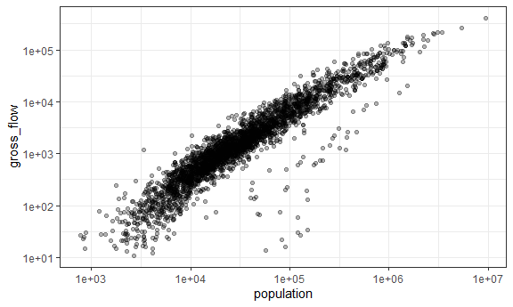

```
ggplot(gross_flow_joined, aes(x = gross_flow_rate)) +
  geom_density(fill = "grey") +
  theme_bw() +
  labs(
    title = "Density of Gross Flow Rate",
    x = "Gross flow (per 1000)",
    y = "Density"
  )
```

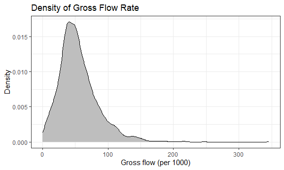

I then examined the distributions of the continuous predictors and the distribution of RUCC. Several continuous variables, particularly median household income, housing rent, and population, were right-skewed. To reduce skewness and improve interpretability, these variables were log-transformed before model fitting. I also assessed the bivariate relationships between gross flow rate and each candidate predictor using scatterplots with smooth trend lines, and compared gross flow rate across RUCC categories using boxplots.

```
eda_long = gross_flow_joined |>
  select(
    median_household_income,
    unemp_percent,
    rent50_2,
    population,
    sex_ratio,
    young_share
  ) |>
  pivot_longer(
    cols = everything(),
    names_to = "variable",
    values_to = "value"
  )

ggplot(eda_long, aes(x = value)) +
  geom_density(fill = "steelblue") +
  facet_wrap(~ variable, scales = "free", ncol = 2) +
  labs(
    x = NULL,
    y = "Density",
    title = "Distributions of raw continuous variables"
  ) +
  theme_minimal()
```

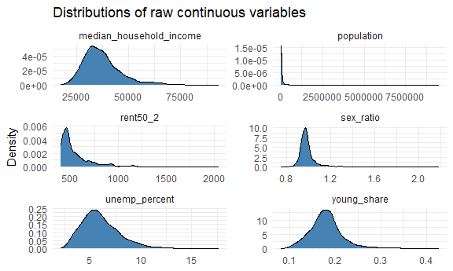

```
ggplot(gross_flow_joined, aes(x = as.factor(rucc))) +
  geom_bar() +
  theme_bw() +
  labs(
    title = "Distribution of RUCC",
    x = "RUCC",
    y = "Count"
  )
```

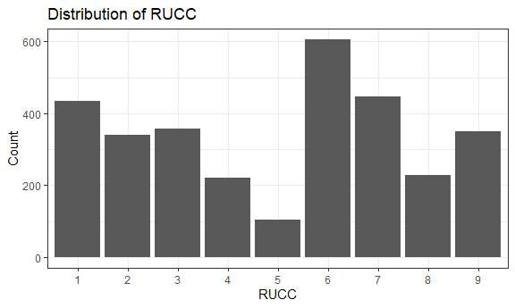

```
analysis_df =
  gross_flow_joined |>
  mutate(
      rucc = factor(rucc),
      log_income = log(median_household_income),
      log_rent = log(rent50_2),
      log_population = log(population)
    )

# density plot after taking log
eda_long_2 = analysis_df |>
  select(
    log_income,
    log_rent,
    log_population
  ) |>
  pivot_longer(
    cols = everything(),
    names_to = "variable",
    values_to = "value"
  )

ggplot(eda_long_2, aes(x = value)) +
  geom_density(fill = "steelblue") +
  facet_wrap(~ variable, scales = "free", ncol = 2) +
  labs(
    x = NULL,
    y = "Density",
    title = "Distributions of adjusted continuous variables"
  ) +
  theme_minimal()
```

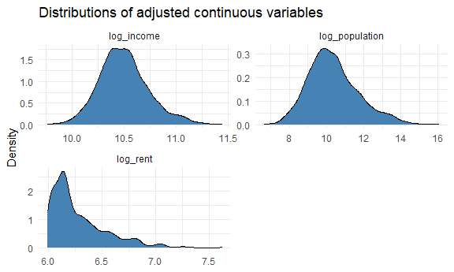

Find out the relationship between gross flow rate and the predictors.

```
analysis_df |>
  select(gross_flow_rate, log_income, unemp_percent, log_rent, log_population, sex_ratio, young_share) |>
  pivot_longer(
    cols = c(log_income, unemp_percent, log_rent, log_population, sex_ratio, young_share),
    names_to = "predictor",
    values_to = "x"
  ) |>
  ggplot(aes(x = x, y = gross_flow_rate)) +
  geom_point(alpha = 0.2) +
  geom_smooth(se = FALSE) +
  facet_wrap(~predictor, scales = "free_x") +
  theme_bw()
```

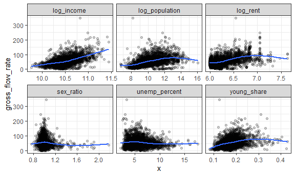

```
y_upper = quantile(analysis_df$gross_flow_rate, 0.99, na.rm = TRUE)

ggplot(analysis_df, aes(x = factor(rucc), y = gross_flow_rate)) +
  geom_boxplot(outlier.shape = NA) +
  geom_jitter(width = 0.2, alpha = 0.2, size = 0.8) +
  coord_cartesian(
    ylim = c(min(analysis_df$gross_flow_rate, na.rm = TRUE),
             y_upper) ) +
  theme_bw() +
  labs( title = "Gross Flow by RUCC",
        x = "RUCC",
        y = "Gross Flow Rate" )
```

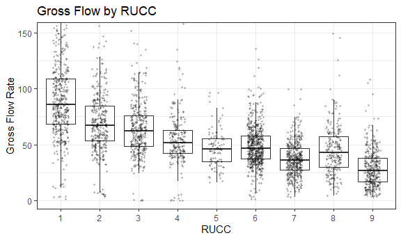

Based on these exploratory plots, log-transformed income, log-transformed rent, log-transformed population, young population share, and RUCC were retained as candidate predictors. In contrast, sex ratio and unemployment rate were excluded from the main model because they showed little clear or consistent relationship with gross flow rate in the exploratory stage.

### Correlation assessment and variable selection

After the exploratory stage, I assessed correlation among the retained predictors using a Spearman correlation matrix. ChatGPT were consulted to help identify an appropriate way to assess association among predictors that included both continuous and categorical variables. Based on this guidance, Spearman correlation was used as a practical screening tool before model fitting to identify potentially redundant variables. The strongest correlation was observed between log population and RUCC (Spearman correlation = -0.74), suggesting substantial overlap in the variation captured by these two measures. Because RUCC was more directly aligned with the urban-rural structure of counties and population was already accounted for through an offset term in the final count model, log population was excluded from the final predictor set. The final model therefore retained log household income, RUCC, log rent, and young population share.

```
cor_mat = analysis_df |>
  select(
    log_income,
    rucc,
    log_rent,
    log_population,
    young_share
  ) |>
  drop_na() |>
  mutate(
    rucc = as.numeric(as.character(rucc))
  ) |>
  cor(method = "spearman")

cor_long = as.data.frame(as.table(cor_mat))

ggplot(cor_long, aes(x = Var1, y = Var2, fill = Freq)) +
  geom_tile(color = "white") +
  geom_text(aes(label = round(Freq, 2)), size = 4) +
  scale_fill_gradient2(
    low = "#2166ac",
    mid = "white",
    high = "#b2182b",
    midpoint = 0,
    limits = c(-1, 1)
  ) +
  labs(
    x = NULL,
    y = NULL,
    fill = "Spearman\ncorrelation",
    title = "Correlation among analysis variables"
  ) +
  theme_minimal() +
  theme(
    axis.text.x = element_text(angle = 45, hjust = 1)
  )
```

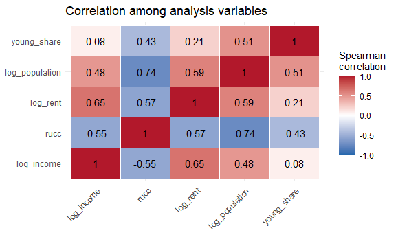

### Statistical modeling

The final model was fitted using a generalized additive model (GAM) with a negative binomial distribution and log link. After examining the observed data patterns, I discussed possible modeling strategies with ChatGPT, including how to handle a count outcome, population differences across counties, and the possibility of nonlinear relationships for some predictors. Based on these considerations, I determined that a GAM was the most appropriate choice for the analysis. Log household income and RUCC were included as parametric terms, while log rent and young population share were modeled using smooth functions. To account for differences in county size, log population was included as an offset term. Model estimation was carried out using restricted maximum likelihood (REML).

```
fit_gam_nb = mgcv::gam(
  gross_flow ~ log_income + rucc +
    s(log_rent) +
    s(young_share) +
    offset(log(population)),
  family = nb(),
  data = analysis_df,
  method = "REML"
)

summary(fit_gam_nb)
```

```
Family: Negative Binomial(5.166)
Link function: log

Formula:
gross_flow ~ log_income + rucc + s(log_rent) + s(young_share) +
    offset(log(population))

Parametric coefficients:
            Estimate Std. Error z value Pr(>|z|)
(Intercept) -9.75535    0.54315 -17.961  < 2e-16 ***
log_income   0.67608    0.05106  13.241  < 2e-16 ***
rucc2       -0.13774    0.03445  -3.999 6.37e-05 ***
rucc3       -0.17188    0.03615  -4.755 1.99e-06 ***
rucc4       -0.29038    0.04080  -7.117 1.10e-12 ***
rucc5       -0.44611    0.05193  -8.591  < 2e-16 ***
rucc6       -0.29629    0.03596  -8.238  < 2e-16 ***
rucc7       -0.55433    0.03773 -14.692  < 2e-16 ***
rucc8       -0.31358    0.04464  -7.024 2.16e-12 ***
rucc9       -0.69550    0.04348 -15.997  < 2e-16 ***
---
Signif. codes:  0 ‘***’ 0.001 ‘**’ 0.01 ‘*’ 0.05 ‘.’ 0.1 ‘ ’ 1

Approximate significance of smooth terms:
                 edf Ref.df Chi.sq p-value
s(log_rent)    4.882  5.989   21.6 0.00154 **
s(young_share) 7.164  8.223  153.0 < 2e-16 ***
---
Signif. codes:  0 ‘***’ 0.001 ‘**’ 0.01 ‘*’ 0.05 ‘.’ 0.1 ‘ ’ 1

R-sq.(adj) =  0.702   Deviance explained =   41%
-REML =  24380  Scale est. = 1         n = 3071
```

```
plot(fit_gam_nb, pages = 1)
```

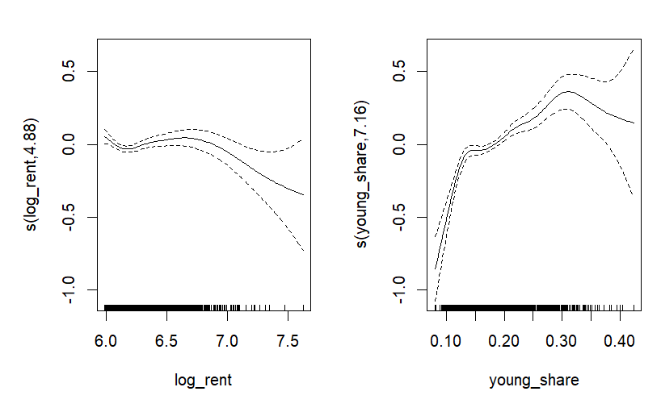

## Result

Other migration patterns, such as net migration or directional flows between urban and rural counties, may provide additional insight, but this analysis focused on gross migration flow as a county-level measure of overall migration intensity.

## Data Sources

### Data Sources

- [U.S. Census Bureau: 2003 SAIPE State and County Estimates](https://www.census.gov/data/datasets/2003/demo/saipe/2003-state-and-county.html)
- [U.S. Bureau of Labor Statistics: Labor force data by county, 2003 annual averages](https://www.bls.gov/lau/tables.htm)
- [USDA Economic Research Service: 2003 Rural-Urban Continuum Codes](https://www.ers.usda.gov/data-products/rural-urban-continuum-codes/documentation)
- [HUD USER: FY2003 50th Percentile Rents, Data by County](https://www.huduser.gov/portal/datasets/50per.html)
- [U.S. Census Bureau: Intercensal Estimates of the Resident Population by Five-Year Age Groups and Sex for Counties, 2000-2010](https://www.census.gov/data/datasets/time-series/demo/popest/intercensal-2000-2010-counties.html)

# 5

NLP Analysis: Extract and analyze common themes or factors driving migration by scraping relevant news articles from the top migration counties.